# Лабораторная работа № 1

Математическое моделирование

Королев И.А.

Российский университет дружбы народов, Москва, Россия

# Информация

## Докладчик

- Королев Иван Андреевич
- Студент
- Российский университет дружбы народов

# Цель работы

Вспомнить и закрепить навыки работы с git и markdown.

# Теоретическое введение

Markdown — облегчённый язык разметки, созданный с целью обозначения форматирования в простом тексте, с максимальным сохранением его читаемости человеком, и пригодный для машинного преобразования в языки для продвинутых публикаций.

Git — это инструмент DevOps, используемый для управления исходным кодом . Это бесплатная система контроля версий с открытым исходным кодом, которая позволяет эффективно управлять как небольшими, так и очень большими проектами. Git используется для отслеживания изменений в исходном коде, позволяя нескольким разработчикам работать вместе над нелинейной разработкой.

# Выполнение лабораторной работы

# Установка имени и электронной почты.

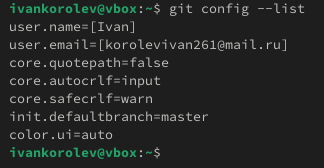

Установка имени и электронной почты

# Настройка core.autocrlf

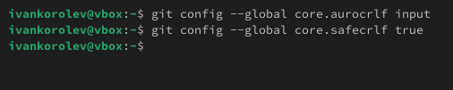

переводы строк текстовых файлов

# Установка отображения unicode

Установка отображения unicode

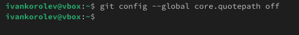

unicode

# Создание проекта.

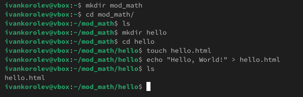

Создаём страницу «Hello, World»

# Создаём репозиторий, добавляем файл в репозиторий и проверяем состояние репозитория.

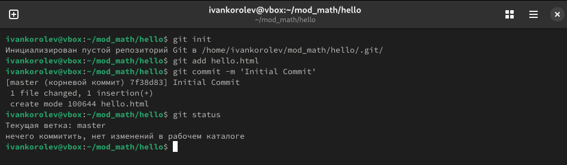

Репозиторий

# Внесение изменений. Добавим HTML-теги к нашему приветствию.

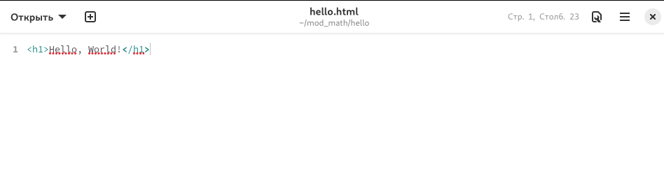

HTML-теги

# Проверим состояние рабочего каталога.

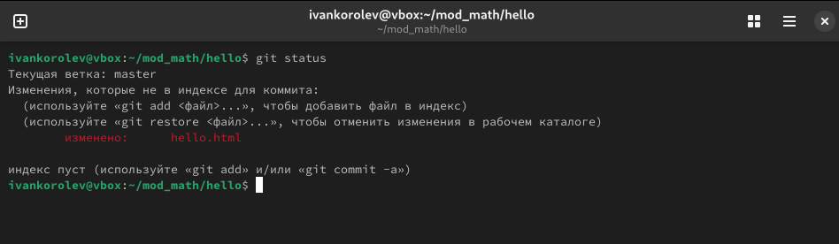

состояние рабочего каталога

# Индексация изменений

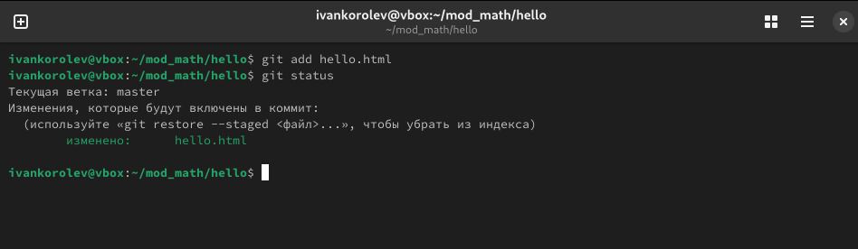

Проиндексируем изменения и проверим состояния

# Коммиты изменений.

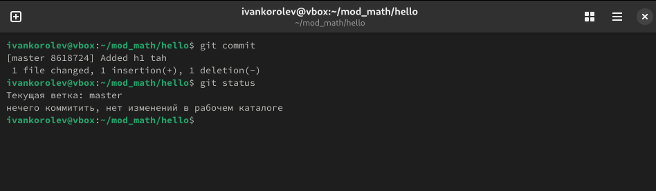

Коммиты изменений

# Добавляем стандартные теги html и body

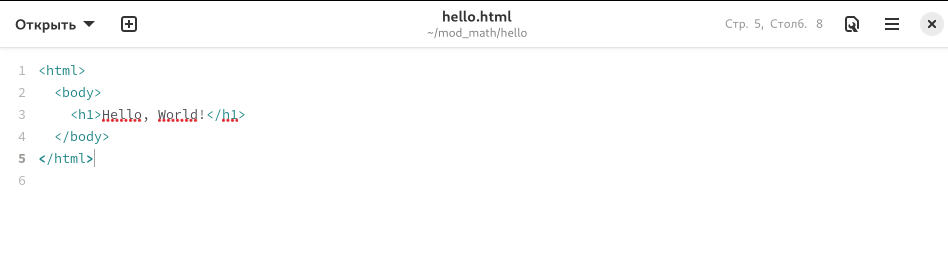

HTML-теги

# Добавляем стандартные теги html и body

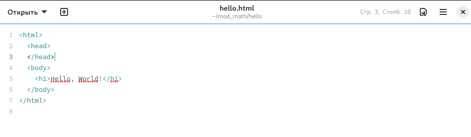

head

# Добавляем стандартные теги html и body

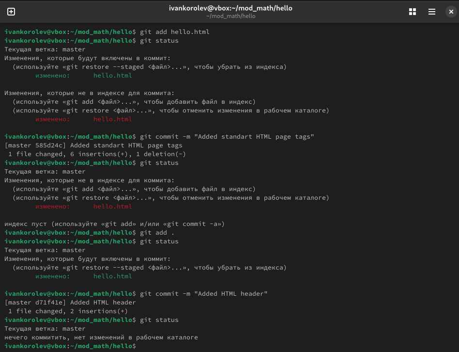

HTML-теги

# git log

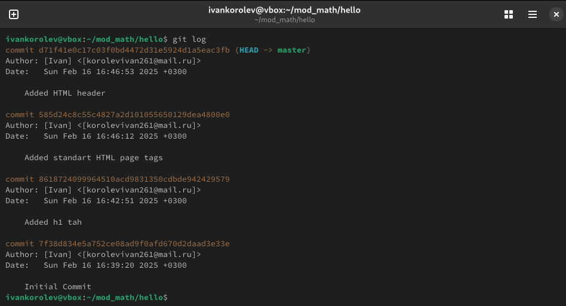

Список произведенных изменений

# Отмена локальных изменений (до индексации)

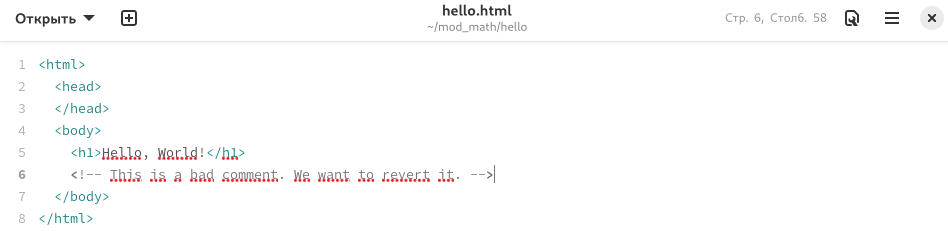

Вносим изменение в файл hello.html

# Отмена локальных изменений (до индексации)

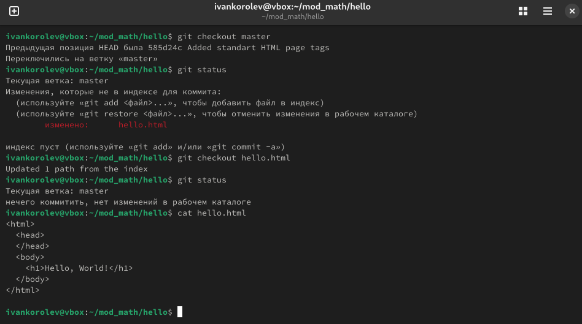

отменяем изменения

# Отмена проиндексированных изменений (перед коммитом)

Вносим изменение в файл hello.html в виде нежелательного комментария и проиндексируем изменения. Проверяем состояние рабочего каталога. Выполняем сброс буферной зоны.

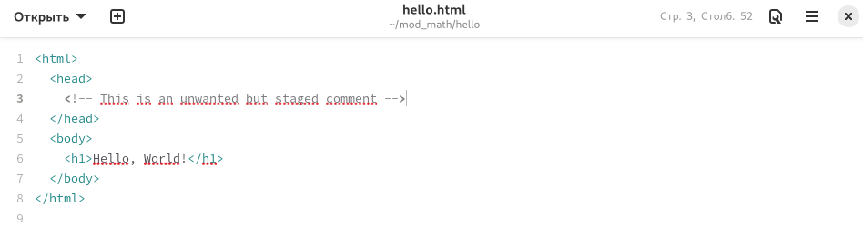

Вносим изменение в файл hello.html

# Отмена проиндексированных изменений (перед коммитом)

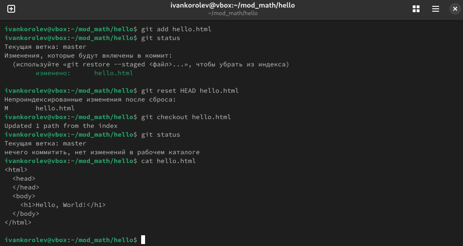

отменяем изменения

# Отмена коммитов

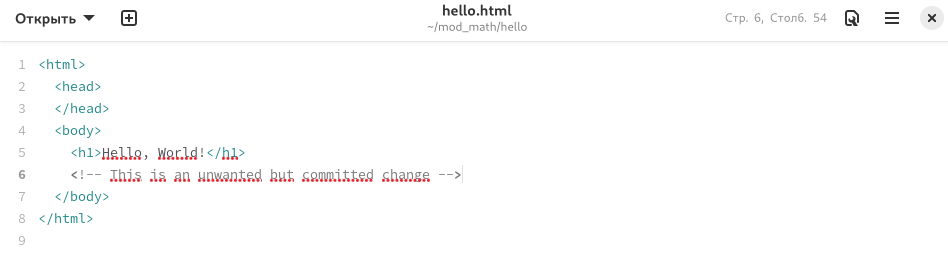

Вносим изменение в файл hello.html

# Отмена коммитов

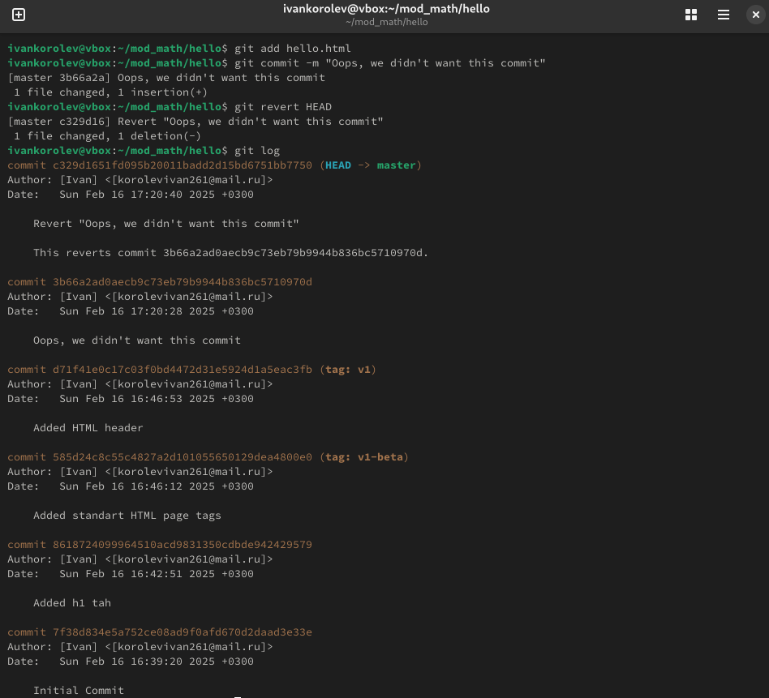

отменяем изменения

# Удаление коммиттов из ветки

Команда git reset.Для начала отмечаем эту ветку и удаляем коммит из ветки.

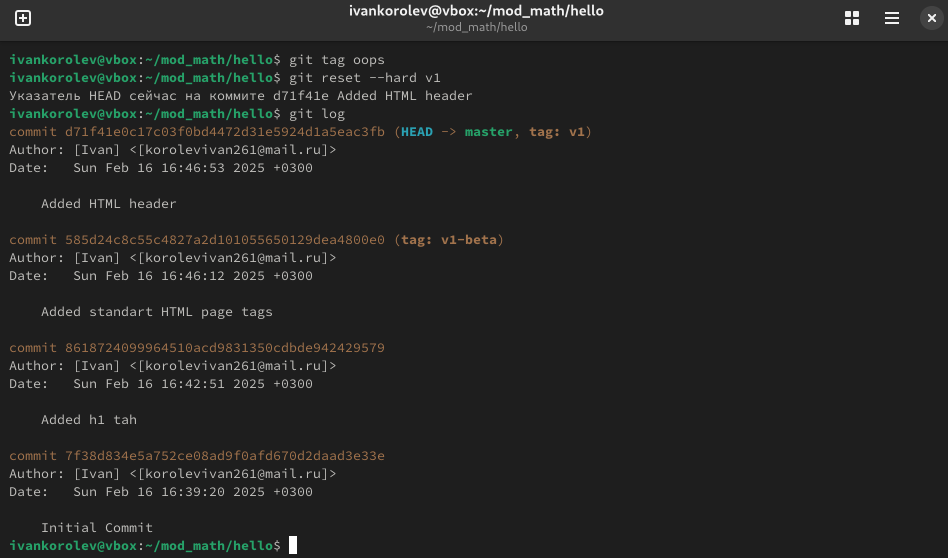

git reset

# Удаление тега oops

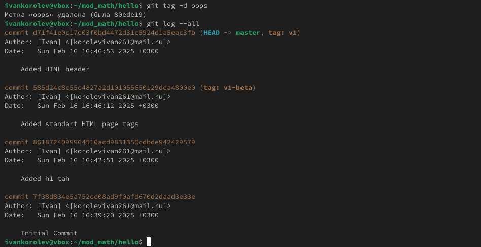

git tag -d oops

# Перемещение файлов

Переместите файл hello.html в каталог lib и Коммит в новый каталог.

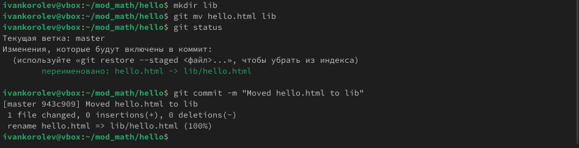

git mv

# Подробнее о структуре

Добавление index.html

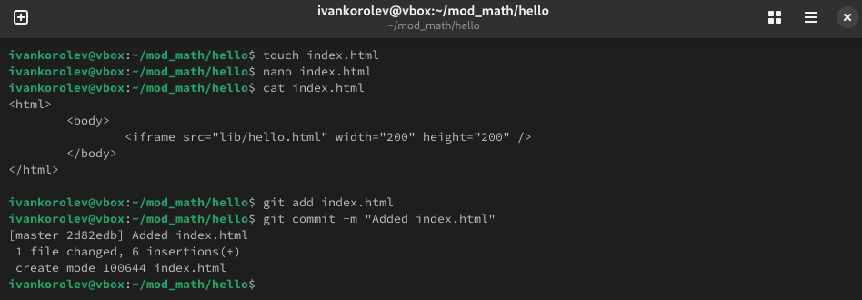

index.html

# Git внутри: Каталог .git

Git внутри: Каталог .git

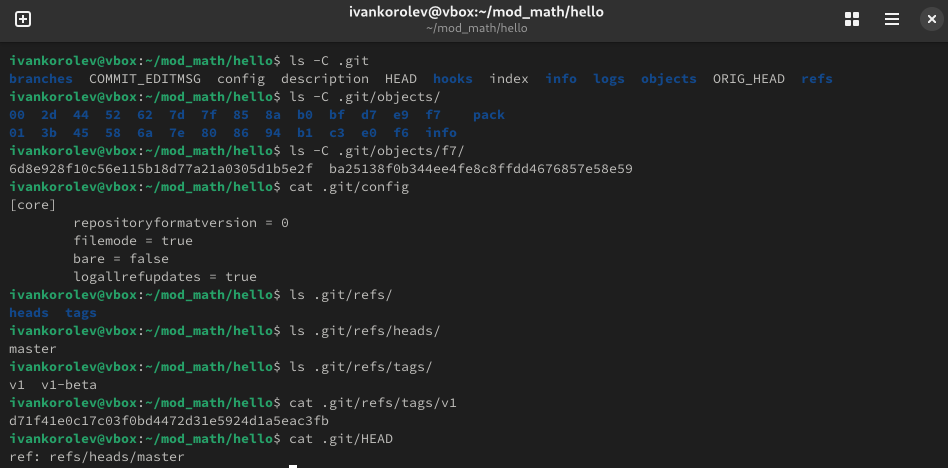

.git

# Работа непосредственно с объектами git

Поиск последнего коммита. Исследуйте git репозиторий вручную самостоятельно. Смотрите, удастся ли вам найти оригинальный файл hello.html с самого первого коммита вручную по ссылкам SHA1 хэша в последнем коммите.

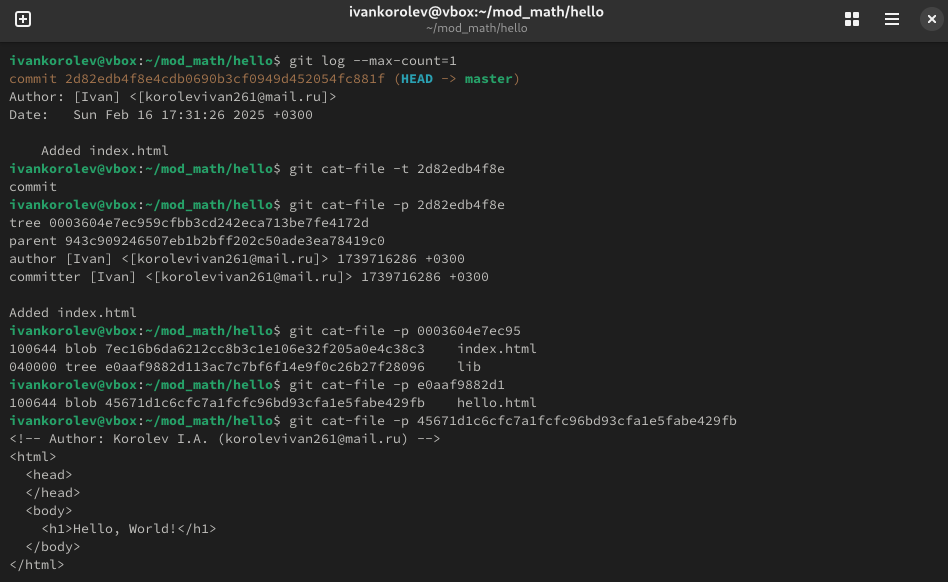

Поиск последнего коммита

# Дополнительное задание. Работа непосредственно с объектами git

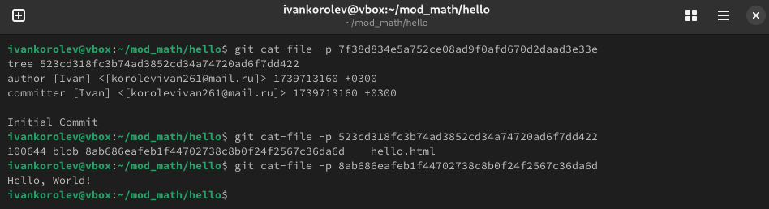

Задание